# Chapter 7 Moving Beyond Linearity

## explore other relationships with explained wage variable

```r
# explore other relationships with wage variable

library(splines)
fit = smooth.spline(wage ~ age, df=3)
fit2 = smooth.spline(wage ~ age, cv=TRUE)
fit2$df
```

```
[1] 6.794596
```

```r
plot (age , wage , cex = .5, col = " darkgrey ")
lines (fit , col = " red ", lwd = 2)
```

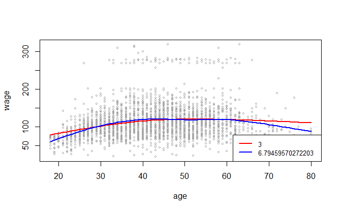

```r
lines (fit2 , col = " blue ", lwd = 2)
legend ("bottomright", legend = c("3", fit2$df),
col = c("red", "blue"), lty = 1, lwd = 2, cex = .8)
```

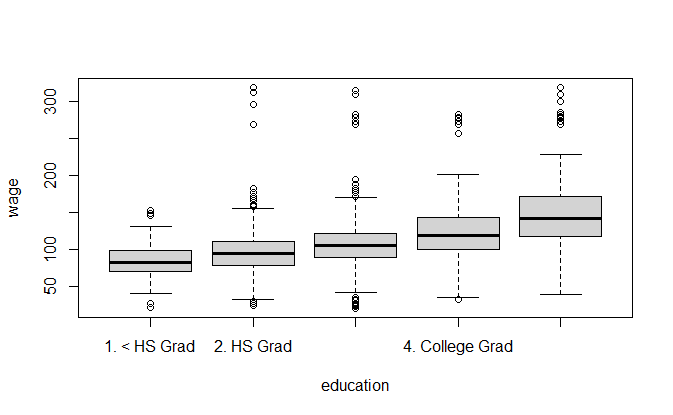

```r
boxplot(wage ~ education)
```

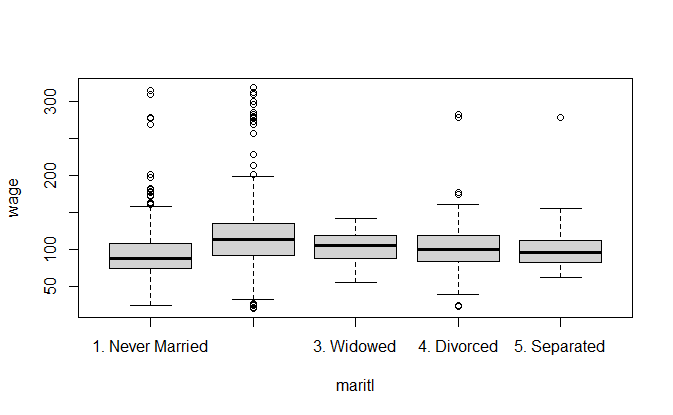

```r
boxplot(wage ~ maritl)
```

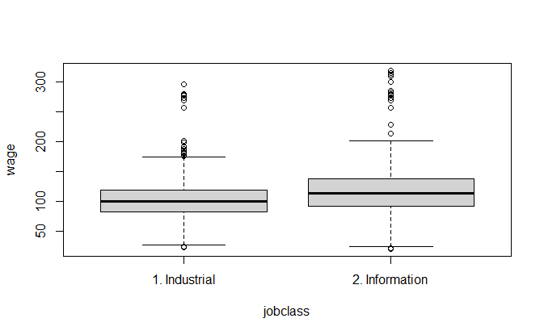

```r
boxplot(wage ~ jobclass)
```

```r
NA
NA
NA
NA
```

### education:

There is a general rising trend with outliers in education higher than HS Grad. In general the outliers are further away from the main bell curve for lower levels of education.

### marital status

High amount of outliers with married and never married people. Married people seem to have higher income.

### job class

Information seems to have slightly higher mean value and deviation

```r
library(gam)
```

```r
fit = gam(wage ~ jobclass)
summary(fit)
```

```
Call: gam(formula = wage ~ jobclass)
Deviance Residuals:
     Min       1Q   Median       3Q      Max
-100.507  -25.362   -6.117   15.697  197.750

(Dispersion Parameter for gaussian family taken to be 1667.294)

    Null Deviance: 5222086 on 2999 degrees of freedom
Residual Deviance: 4998547 on 2998 degrees of freedom
AIC: 30774.5

Number of Local Scoring Iterations: 2

Anova for Parametric Effects
            Df  Sum Sq Mean Sq F value    Pr(>F)
jobclass     1  223538  223538  134.07 < 2.2e-16 ***
Residuals 2998 4998547    1667
---
Signif. codes:  0 ‘***’ 0.001 ‘**’ 0.01 ‘*’ 0.05 ‘.’ 0.1 ‘ ’ 1
```

```r
coef(fit)
```

```
           (Intercept) jobclass2. Information
             103.32113               17.27159
```

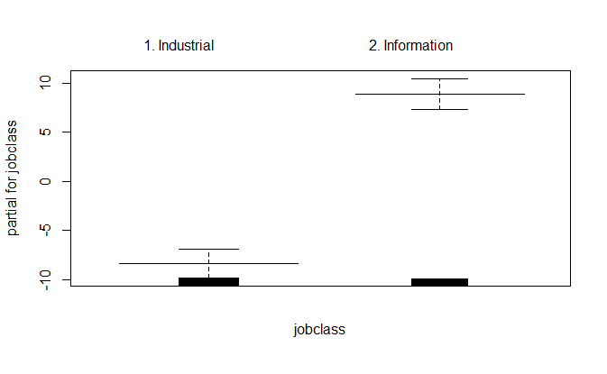

```r
plot ( fit , se = TRUE , col = " blue ")
```

```r
fit = gam(wage ~ s(age, 4) + jobclass + education)
summary(fit)
```

```
Call: gam(formula = wage ~ s(age, 4) + jobclass + education)
Deviance Residuals:
     Min       1Q   Median       3Q      Max
-112.375  -19.967   -3.021   14.272  212.216

(Dispersion Parameter for gaussian family taken to be 1238.216)

    Null Deviance: 5222086 on 2999 degrees of freedom
Residual Deviance: 3702265 on 2990 degrees of freedom
AIC: 29889.9

Number of Local Scoring Iterations: NA

Anova for Parametric Effects
            Df  Sum Sq Mean Sq F value    Pr(>F)
s(age, 4)    1  199870  199870  161.42 < 2.2e-16 ***
jobclass     1  174330  174330  140.79 < 2.2e-16 ***
education    4  916197  229049  184.98 < 2.2e-16 ***
Residuals 2990 3702265    1238
---
Signif. codes:  0 ‘***’ 0.001 ‘**’ 0.01 ‘*’ 0.05 ‘.’ 0.1 ‘ ’ 1

Anova for Nonparametric Effects
            Npar Df Npar F     Pr(F)
(Intercept)
s(age, 4)         3 40.913 < 2.2e-16 ***
jobclass
education
---
Signif. codes:  0 ‘***’ 0.001 ‘**’ 0.01 ‘*’ 0.05 ‘.’ 0.1 ‘ ’ 1
```

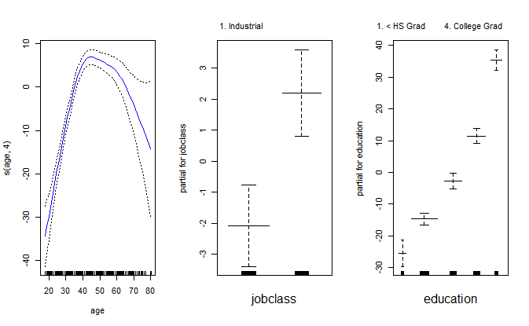

```r
par ( mfrow = c(1, 3))
plot ( fit , se = TRUE , col = " blue ")
```

```r
#plot(maritl , wage , cex = .5, col = " darkgrey ")
#lines(fit , col = " red ", lwd = 2)
#legend("bottomright", legend = c(fit1$df),
#col = c("red"), lty = 1, lwd = 2, cex = .8)
```

**(8)**

```r
detach(Wage)
attach(Auto)
help(Auto)
```

**(a)**

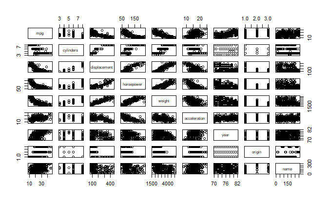

The Auto dataset looks to have non-linear relationships with displacement, horsepower, weight and maybe year from the pair plots displayed above

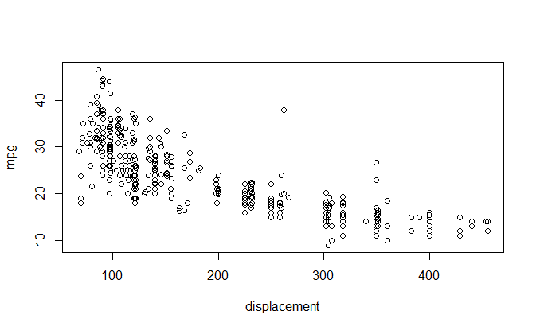

```r
plot(displacement, mpg)
```

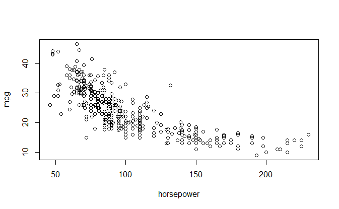

```r
plot(horsepower, mpg)
```

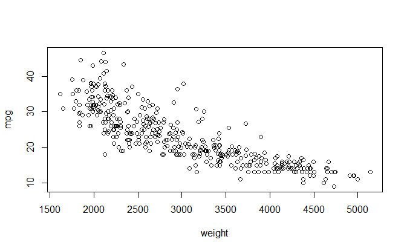

```r
plot(weight, mpg)
```

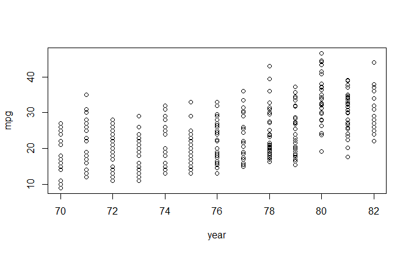

```r
plot(year, mpg)
```

```r
fit = smooth.spline(mpg ~ horsepower, cv=TRUE)
fit$df
```

```
[1] 5.784761
```

```r
plot (horsepower, mpg, cex = .5, col = " darkgrey ")
lines (fit , col = "red", lwd = 2)
```

[figure not shown]

```r
legend ("topright", legend = c(fit2$df),
col = c("red"), lty = 1, lwd = 2, cex = .8)
```

```r
fit = smooth.spline(mpg ~ displacement, cv=TRUE)
fit$df
```

```
[1] 20.0332
```

```r
plot (displacement, mpg, cex = .5, col = " darkgrey ")
lines (fit , col = "red", lwd = 2)
```

[figure not shown]

```r
legend ("topright", legend = c(fit2$df),
col = c("red"), lty = 1, lwd = 2, cex = .8)
```

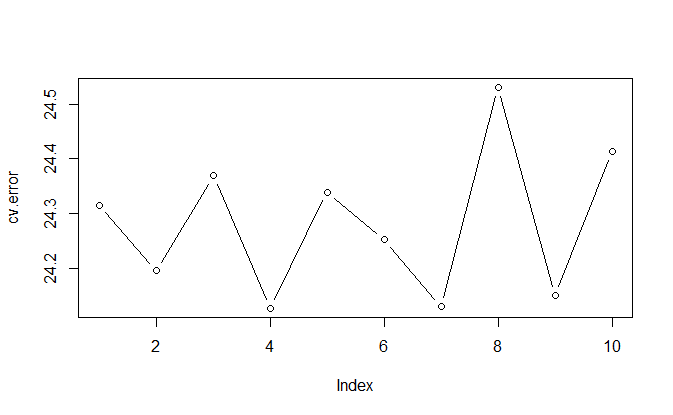

```r
fit = smooth.spline(mpg ~ horsepower, cv=TRUE)
cv.error = rep(NA, 10)
for (i in 1:10){
  fit = glm(mpg~horsepower, data=Auto)
  cv.error[i] = cv.glm(Auto, fit, K=10)$delta[1]
}
plot(cv.error, type = 'b')
```

```r
fit1 = glm(mpg ~ displacement)
fit3 = glm(mpg ~ poly(displacement, 3))
fit4 = glm(mpg ~ poly(displacement, 4))
displim = range(displacement)
disp.grid = seq(displim[1], displim[2])
preds1 = predict(fit1, newdata = list(displacement=disp.grid))
preds3 = predict(fit3, newdata = list(displacement=disp.grid))
preds4 = predict(fit4, newdata = list(displacement=disp.grid))
plot (displacement, mpg, cex = .5, col = " darkgrey ")
lines (preds1, col = "red", lwd = 2)
```

```r
lines (preds3, col = "blue", lwd = 2)
lines (preds4, col = "green", lwd = 2)
```

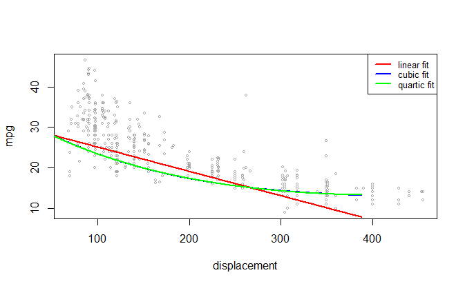

```r
legend ("topright", legend = c("linear fit", "cubic fit", "quartic fit"),
col = c("red", "blue", "green"), lty = 1, lwd = 2, cex = .8)
```

**(9)**

```r
detach(Auto)
attach(Boston)
```

**(a)** **(b)** **(c)**

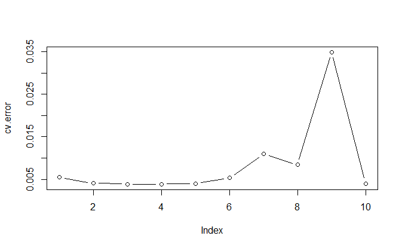

```r
cv.error = rep(NA, 10)
for (i in 1:10){
  glm.fit = glm(nox~poly(dis,i))
  cv.error[i] = cv.glm(Boston, glm.fit, K=10)$delta[1]
}
plot(cv.error, type='b')
```

2nd degree polynomial seems to be optimal since there is no considerable improvement for higher order polynomials.

```r
glm.fit1 = glm(nox~poly(dis, 1), data = Boston)
glm.fit2 = glm(nox~poly(dis, 2), data = Boston)
glm.fit3 = glm(nox~poly(dis, 3), data = Boston)
glm.fit4 = glm(nox~poly(dis, 4), data = Boston)
glm.fit5 = glm(nox~poly(dis, 5), data = Boston)
glm.fit6 = glm(nox~poly(dis, 6), data = Boston)

dislim = range(dis)
dis.grid = seq(dislim[1], dislim[2])

pred1 = predict(glm.fit1, newdata=list(dis=dis.grid))
pred2 = predict(glm.fit2, newdata=list(dis= dis.grid))
pred3 = predict(glm.fit3, newdata=list(dis= dis.grid))
pred4 = predict(glm.fit4, newdata=list(dis= dis.grid))
pred5 = predict(glm.fit5, newdata=list(dis= dis.grid))
pred6 = predict(glm.fit6, newdata=list(dis= dis.grid))

plot(dis, nox, col="darkgrey", cex=.5)
lines(pred1, col="blue", lwd=2)
```

```r
lines(pred2, col="green", lwd=2)
lines(pred3, col="red", lwd=2)
```

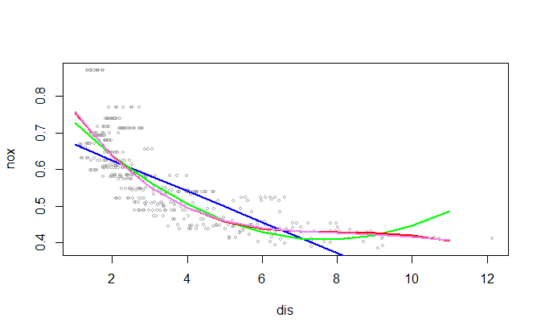

```r
lines(pred4, col="violet", lwd=2)
```

**(d)**

```r
lm.fit = lm(nox ~ bs(dis, df=4), data=Boston)

preds = predict(lm.fit, newdata=list(dis=dis.grid), se=T)

attr(bs(dis, df=4), "knots")
```

```
[1] 3.20745
```

```r
summary(lm.fit)
```

```
Call:
lm(formula = nox ~ bs(dis, df = 4), data = Boston)

Residuals:
      Min        1Q    Median        3Q       Max
-0.124622 -0.039259 -0.008514  0.020850  0.193891

Coefficients:
                 Estimate Std. Error t value Pr(>|t|)
(Intercept)       0.73447    0.01460  50.306  < 2e-16 ***
bs(dis, df = 4)1 -0.05810    0.02186  -2.658  0.00812 **
bs(dis, df = 4)2 -0.46356    0.02366 -19.596  < 2e-16 ***
bs(dis, df = 4)3 -0.19979    0.04311  -4.634 4.58e-06 ***
bs(dis, df = 4)4 -0.38881    0.04551  -8.544  < 2e-16 ***
---
Signif. codes:  0 ‘***’ 0.001 ‘**’ 0.01 ‘*’ 0.05 ‘.’ 0.1 ‘ ’ 1

Residual standard error: 0.06195 on 501 degrees of freedom
Multiple R-squared:  0.7164,    Adjusted R-squared:  0.7142
F-statistic: 316.5 on 4 and 501 DF,  p-value: < 2.2e-16
```

```r
plot(dis, nox, col="darkgray", cex=.5)
lines(preds$fit, col="blue", lwd=2)
```

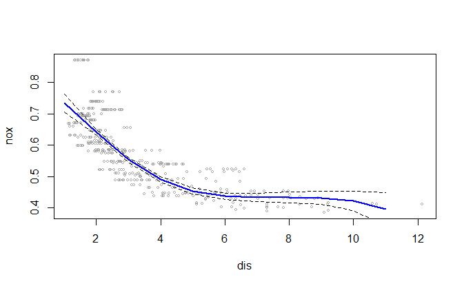

```r
lines(preds$fit+2*preds$se, lty="dashed")
lines(preds$fit-2*preds$se, lty="dashed")
```

- knots are automatically selected automatically at uniform quantiles (1 knot means 50th quantile)
- summary() of the model shows that the model is statistically significant.
- The fit is similar to the 3rd degree polynomial fit.

**(e)**

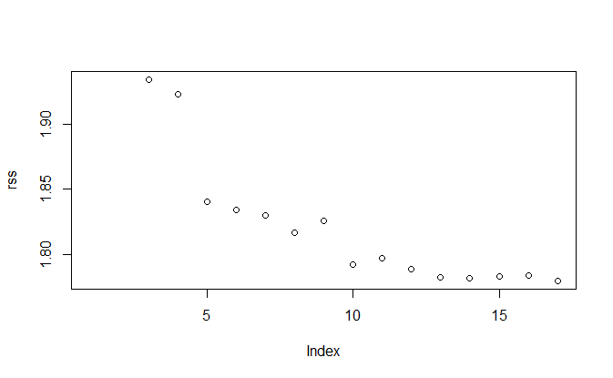

```r
rss = rep(NA, 15)
for (i in 3:17){
  lm.fit = lm(nox ~ bs(dis, df=i), data=Boston)
  preds = predict(lm.fit, newdata=Boston)
  rss[i] = sum((preds - nox)**2)
}
plot(rss)
```

After 10 degrees of freedom there isnt a noticeable reduction in train RSS.

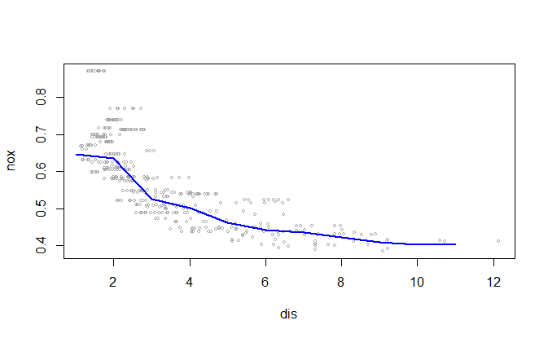

```r
lm.fit = lm(nox ~ bs(dis, df=10), data=Boston)
pred = predict(lm.fit, newdata=list(dis=dis.grid))
plot(dis, nox, col="darkgray", cex=.5)
lines(pred, col="blue", lwd=2)
```

**(f)**

```r
rss.train = rep(NA, 17)
rss.test = rep(NA, 17)
for (i in 3:19){
  glm.fit = glm(nox ~ bs(dis, df=i), data=Boston)
  preds = predict(glm.fit, newdata=Boston)
  rss.train[i-2] = mean((preds - nox)**2)

  rss.test[i-2] = cv.glm(Boston, glm.fit, K=10)$delta[1]

}
rss.lim = c(min(min(rss.test), min(rss.train)), max(max(rss.test), max(rss.train)))
plot(3:19, rss.test, type='b', col="orange", ylim=c(rss.lim[1], rss.lim[2]), ylab="error")
lines(3:19, rss.train, type='b', col="blue", lwd=2)
```

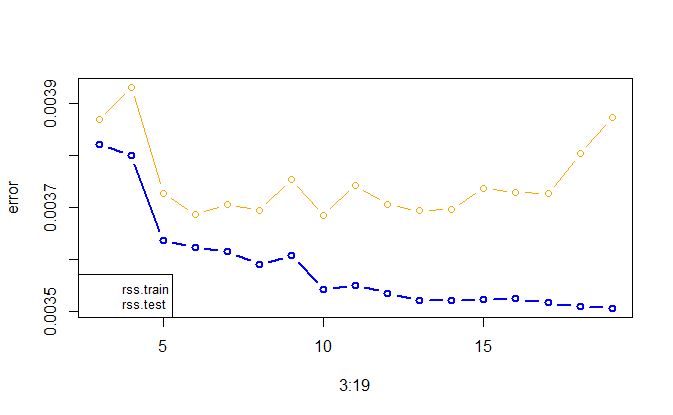

```r
legend("bottomleft", legend=c("rss.train", "rss.test"), col = par("blue", "orange"), lty = 1, lwd = 2, cex = .8)
```

Cross validation error shows a significant drop in rss error for 5-6 degrees of freedom (orange). There is not sufficient evidence to choose a greater value than 6 degrees of freedom.

**(10)**

```r
require(caTools)
```

```r
college.sample = sample.split(College$Outstate, SplitRatio = 0.80)
college.train = College[college.sample,]
college.test = College[college.sample==FALSE,]
```

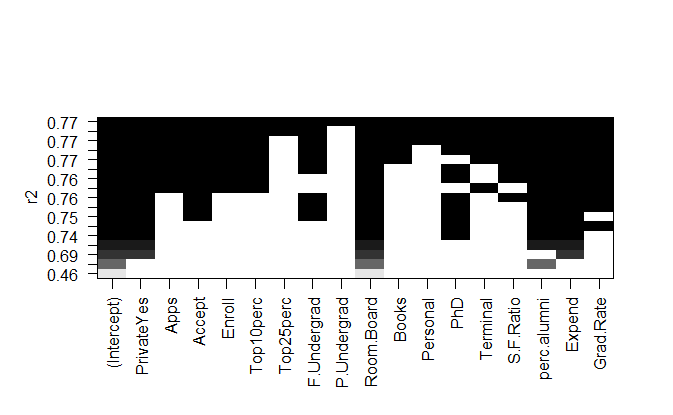

```r
## picking the best 8 variables for model prediction according to step-forward selection
regfit.full = regsubsets(Outstate~., data = college.train, nvmax=17)
regfit.summary = summary(regfit.full)

plot ( regfit.full , scale = "r2")
```

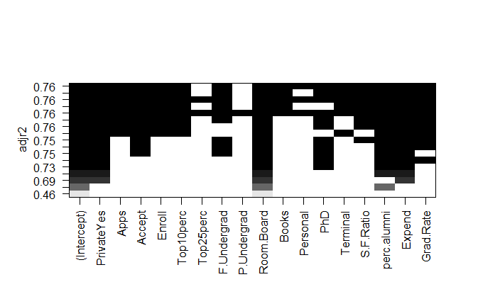

```r
plot ( regfit.full , scale = "adjr2")
```

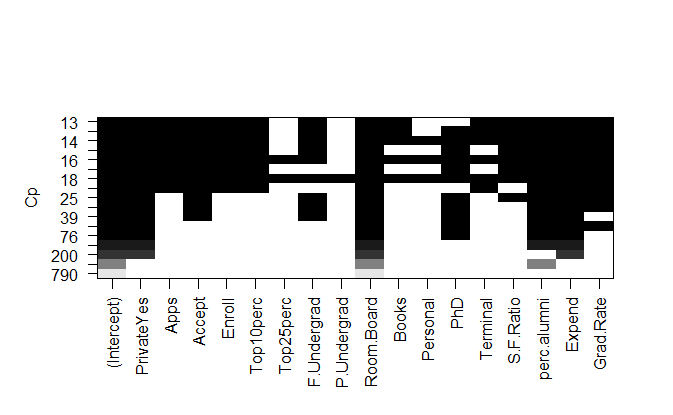

```r
plot ( regfit.full , scale = "Cp")
```

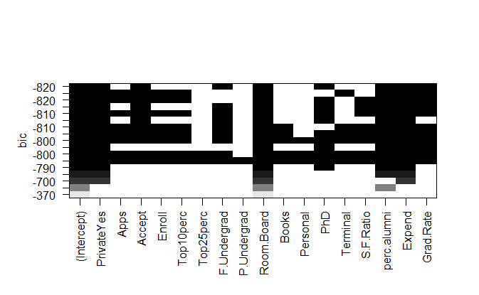

```r
plot ( regfit.full , scale = "bic")
```

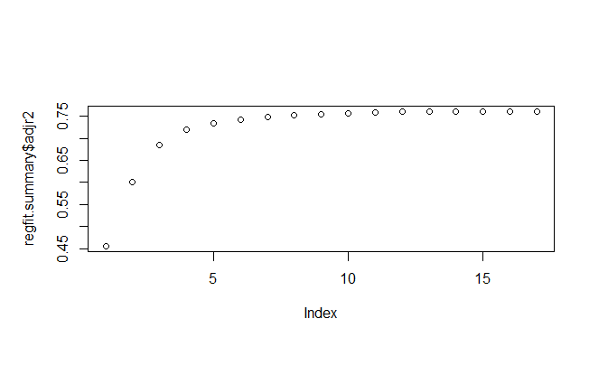

```r
plot (regfit.summary$adjr2)
```

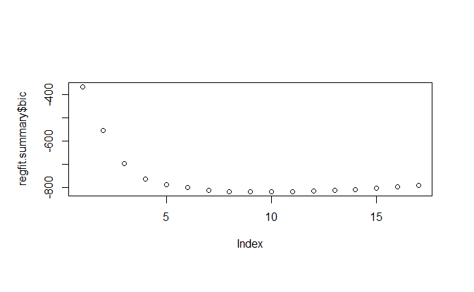

```r
plot (regfit.summary$bic)
```

From the adjr2 and bic plot above there seems to top off with 6 variables and there are only small improvements after.

```r
# the chosen parameters are:
coef(regfit.full, 6)
```

```
  (Intercept)    PrivateYes    Room.Board           PhD   perc.alumni        Expend     Grad.Rate
-3503.4835877  2584.6398508     1.1217445    31.1465202    48.6550854     0.2195577    25.7143818
```

**(b)**

```r
gam.fit = gam(Outstate ~ Private + s(Room.Board, 4) + s(PhD, 4) + perc.alumni + s(Expend, 4) + s(Grad.Rate, 4), data=college.train)
preds = predict(gam.fit, newdata = college.test)
rss = mean((preds-college.test$Outstate)^2)
mse
```

[output not shown]

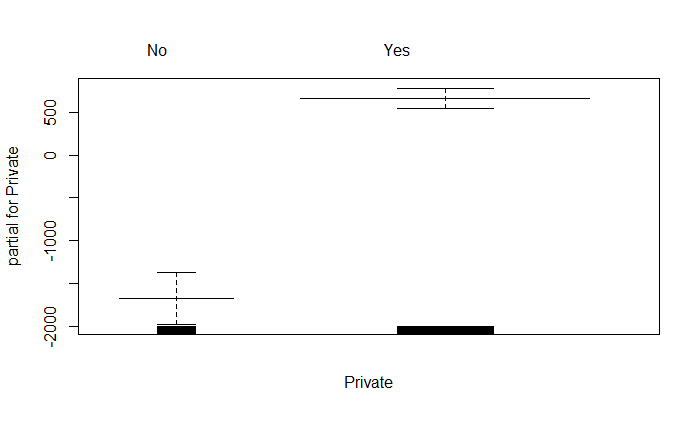

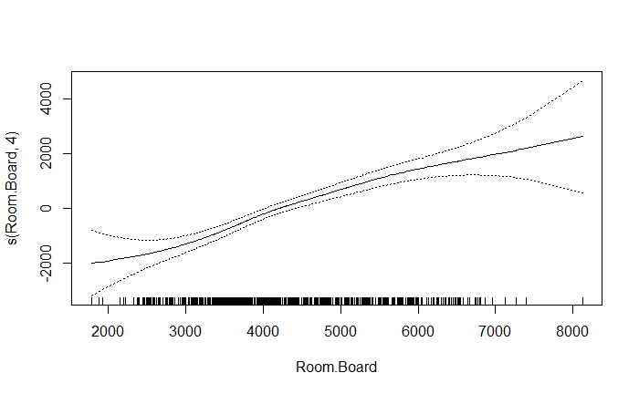

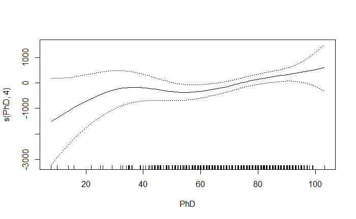

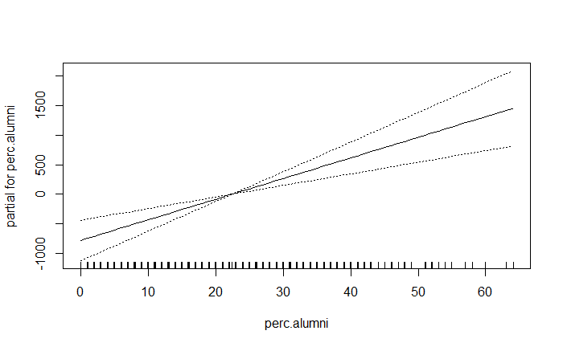

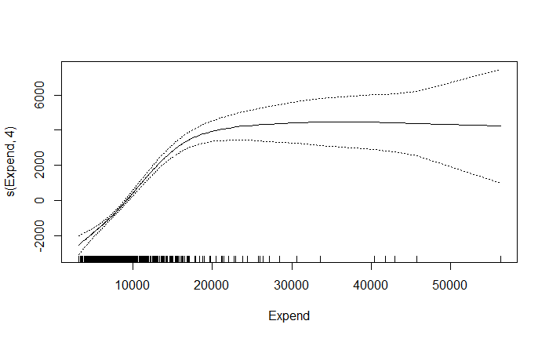

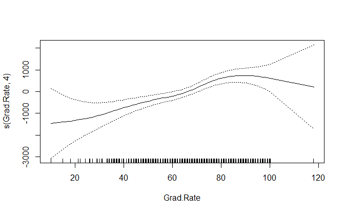

```r
plot(gam.fit, se=TRUE)
```

**(d)** ### check if there is evidence of a non-linear relationship

```r
gam.fit = gam(Outstate ~ Private + Room.Board + PhD + perc.alumni + Expend + Grad.Rate, data=college.train)
gam.fit1 = gam(Outstate ~ Private + Room.Board + PhD + perc.alumni + Expend + s(Grad.Rate, 4), data=college.train)
gam.fit2 = gam(Outstate ~ Private + s(Room.Board, 4) + PhD + perc.alumni + Expend + Grad.Rate, data=college.train)
gam.fit3 = gam(Outstate ~ Private + Room.Board + s(PhD, 4) + perc.alumni + Expend + Grad.Rate, data=college.train)
gam.fit4 = gam(Outstate ~ Private + Room.Board + PhD + s(perc.alumni, 4) + Expend + Grad.Rate, data=college.train)
gam.fit5 = gam(Outstate ~ Private + Room.Board + PhD + perc.alumni + s(Expend, 4) + Grad.Rate, data=college.train)

anova(gam.fit, gam.fit1)
```

```
Analysis of Deviance Table

Model 1: Outstate ~ Private + Room.Board + PhD + perc.alumni + Expend +
    Grad.Rate
Model 2: Outstate ~ Private + Room.Board + PhD + perc.alumni + Expend +
    s(Grad.Rate, 4)
  Resid. Df Resid. Dev     Df Deviance Pr(>Chi)
1       614 2535896491
2       611 2500115975 2.9999 35780516  0.03289 *
---
Signif. codes:  0 ‘***’ 0.001 ‘**’ 0.01 ‘*’ 0.05 ‘.’ 0.1 ‘ ’ 1
```

```r
anova(gam.fit, gam.fit2)
```

```
Analysis of Deviance Table

Model 1: Outstate ~ Private + Room.Board + PhD + perc.alumni + Expend +
    Grad.Rate
Model 2: Outstate ~ Private + s(Room.Board, 4) + PhD + perc.alumni + Expend +
    Grad.Rate
  Resid. Df Resid. Dev     Df Deviance Pr(>Chi)
1       614 2535896491
2       611 2507977918 2.9999 27918573  0.07849 .
---
Signif. codes:  0 ‘***’ 0.001 ‘**’ 0.01 ‘*’ 0.05 ‘.’ 0.1 ‘ ’ 1
```

```r
anova(gam.fit, gam.fit3)
```

```
Analysis of Deviance Table

Model 1: Outstate ~ Private + Room.Board + PhD + perc.alumni + Expend +
    Grad.Rate
Model 2: Outstate ~ Private + Room.Board + s(PhD, 4) + perc.alumni + Expend +
    Grad.Rate
  Resid. Df Resid. Dev     Df Deviance Pr(>Chi)
1       614 2535896491
2       611 2474215023 3.0002 61681467 0.001629 **
---
Signif. codes:  0 ‘***’ 0.001 ‘**’ 0.01 ‘*’ 0.05 ‘.’ 0.1 ‘ ’ 1
```

```r
anova(gam.fit, gam.fit4)
```

```
Analysis of Deviance Table

Model 1: Outstate ~ Private + Room.Board + PhD + perc.alumni + Expend +
    Grad.Rate
Model 2: Outstate ~ Private + Room.Board + PhD + s(perc.alumni, 4) + Expend +
    Grad.Rate
  Resid. Df Resid. Dev Df Deviance Pr(>Chi)
1       614 2535896491
2       611 2526359085  3  9537405   0.5113
```

```r
anova(gam.fit, gam.fit5)
```

```
Analysis of Deviance Table

Model 1: Outstate ~ Private + Room.Board + PhD + perc.alumni + Expend +
    Grad.Rate
Model 2: Outstate ~ Private + Room.Board + PhD + perc.alumni + s(Expend,
    4) + Grad.Rate
  Resid. Df Resid. Dev     Df  Deviance  Pr(>Chi)
1       614 2535896491
2       611 2143028848 3.0003 392867643 < 2.2e-16 ***
---
Signif. codes:  0 ‘***’ 0.001 ‘**’ 0.01 ‘*’ 0.05 ‘.’ 0.1 ‘ ’ 1
```

From the anova results above that compare a base model with linear relationship between variables to different models with non-linearity added to each specific variable we can tell that:

- There is evidence for a non-linear relationship between Grad.Rate and Outstate (p-value of 3.2%)
- PhD and Outstate (p-value of 0.16%)
- same applies for Expend variable p-value < 2.2e-16
- Room.Board barely misses the mark with a p-value > 6%

**(11)**

**(a)**

```r
set.seed(5)

# Generated dataset
X1 = rnorm(100, sd=2)
X2 = rnorm(100, sd=sqrt(2))
eps = rnorm(100, sd = 1)
b0 = 5; b1=2.5 ; b2=11.5
Y = b0 +b1*X1 + b2*X2 + eps
```

**(b)(c)** keeping beta1 fixed estimate beta2

```r
beta1 = 10
a = Y - beta1*X1
beta2 = lm(a~X2)$coef[2]
beta2
```

```
      X2
10.38818
```

**(d)** keeping beta2 fixed, estimate a new beta1

```r
a = Y - beta2*X2
beta1 = lm(a~X1)$coef[2]
beta1
```

```
      X1
2.634548
```

After just 1 iteration beta1 gets much closer to the real value

**(c)**

```r
beta.estimates = matrix(NA, nrow=10, ncol=3)
beta1 = 10

for (i in 1:10){
  a = Y - beta1*X1
  beta2 = lm(a~X2)$coef[2]
  a = Y - beta2*X2
  lm.fit = lm(a~X1)
  beta0 = lm.fit$coef[1]
  beta1 = lm.fit$coef[2]
  beta.estimates[i,1] = beta0
  beta.estimates[i,2] = beta1
  beta.estimates[i,3] = beta2
}

plot(x=1:10, beta.estimates[,1], type='l', ylim=range(1:15), col="black")
#lines(beta.estimates[,1], type='l')
lines(beta.estimates[,2], type='l', col="blue")
```

```r
lines(beta.estimates[,3], type='l', col="red")

#coefficient estimates from running multiple regression (results from f)
#(Intercept)          X1          X2
#   4.996049    2.526440   11.536752
abline(h=4.996049, col="gray", lty=2)
```

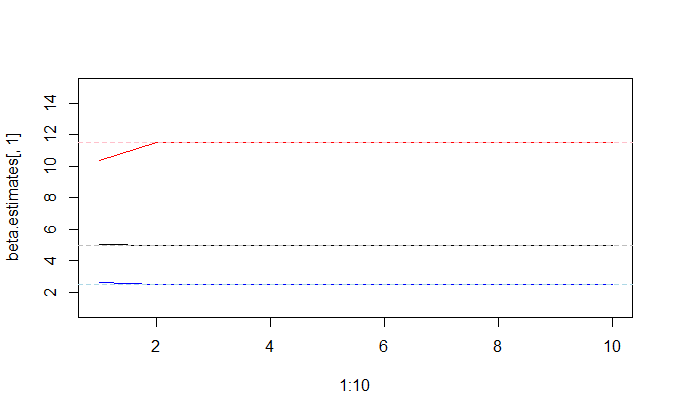

```r
abline(h=2.526440, col="lightblue", lty=2)
abline(h=11.536752, col="pink", lty=2)
```

**(f)**

```r
lm.fit = lm(Y ~ X1 + X2)
lm.fit$coef
```

```
(Intercept)          X1          X2
   4.996049    2.526440   11.536752
```

**(g)** Less tan 4 iterations were needed to get a very good approximation of the coefficients

**(12)**

```r
set.seed(5)
n = 1000
p = 100
# Generated dataset
X = matrix(rnorm(n*p, sd=2), ncol=p)
eps = rnorm(n, sd = 1)
betas = rnorm(p, sd=2)+3
b0 = 2.5
Y = b0 + X %*% betas + eps
```

```r
beta.estimates = matrix(0, nrow=20, ncol=p)
beta0 = rep(10, 20)

for (i in 1:20){
  for (j in 1:p){
    a = Y - X[,-j] %*% beta.estimates[i,-j]
    lm.fit = lm(a~X[,j])
    beta.estimates[i:20, j] = lm.fit$coef[2]
  }
  beta0[i:20] = lm.fit$coef[1]
}
```

```r
plot(x=1:20, beta0, type='l', ylim=range(-5:15), col="black")
beta0
```

```
 [1] 1.694752 2.363453 2.518780 2.534615 2.536267 2.536937 2.537216 2.537308
 [9] 2.537334 2.537341 2.537343 2.537343 2.537343 2.537343 2.537343 2.537343
[17] 2.537343 2.537343 2.537343 2.537343
```

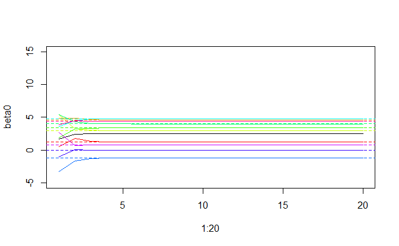

```r
colors = rainbow(10)
for (i in 1:10){
  lines(beta.estimates[,i], col=colors[i], type='l')
  abline(h = betas[i], col=colors[i], lty=2)
}
```

There seems to be convergence after the 3rd/4th iteration